# Distributional semantic analysis

anonymous

16/06/2021

## Setup

Load packages:

```r
library(tidyverse) # for data processing
library(lsa) # for cosine similarity function
library(brms) # for bayesian models
library(effsize) # for cohen's d
library(patchwork) # for double plots
library(tidybayes) # for half-eye plots
```

Load data:

```r
wiki <- read_csv('../data/wiki_word2vec.csv')
```

Quick glance at the structure of this table. Each row is a word, then there’s 300 dimensions from Facebook’s word2vec model.

```r
wiki
```

```
## # A tibble: 999,994 × 301
##    word    dim_1   dim_2   dim_3  dim_4   dim_5   dim_6  dim_7   dim_8   dim_9
##    <chr>   <dbl>   <dbl>   <dbl>  <dbl>   <dbl>   <dbl>  <dbl>   <dbl>   <dbl>
##  1 ","    0.107   0.0089  0.0006 0.0055 -0.0646 -0.06   0.045  -0.0133 -0.0357
##  2 "the"  0.0897  0.016  -0.0571 0.0405 -0.0696 -0.124  0.0301  0.0248 -0.0303
##  3 "."    0.0004  0.0032 -0.0204 0.0479 -0.045  -0.116  0.0142  0.0068 -0.0334
##  4 "and" -0.0314  0.0149 -0.0205 0.0557  0.0205 -0.0405 0.0044 -0.0118 -0.0424
##  5 "of"  -0.0063 -0.0253 -0.0338 0.0178 -0.0966  0.0946 0.0328 -0.0227  0.0628
##  6 "to"   0.0495  0.0411  0.0041 0.0309 -0.0044 -0.115  0.006   0.017   0.0045
##  7 "in"  -0.0234 -0.0268 -0.0838 0.0386 -0.0321  0.0628 0.0281 -0.0252  0.0269
##  8 "a"    0.0047  0.0223 -0.0087 0.025  -0.066   0.0212 0.0178 -0.0149  0.0282
##  9 "\""  -0.0899 -0.0402 -0.022  0.0476  0.0262 -0.121  0.027   0.0168 -0.131
## 10 ":"   -0.0221 -0.0133  0.0161 0.0824  0.187  -0.111  0.0454  0.0146 -0.0213
## # … with 999,984 more rows, and 291 more variables: dim_10 <dbl>, dim_11 <dbl>,
## #   dim_12 <dbl>, dim_13 <dbl>, dim_14 <dbl>, dim_15 <dbl>, dim_16 <dbl>,
## #   dim_17 <dbl>, dim_18 <dbl>, dim_19 <dbl>, dim_20 <dbl>, dim_21 <dbl>,
## #   dim_22 <dbl>, dim_23 <dbl>, dim_24 <dbl>, dim_25 <dbl>, dim_26 <dbl>,
## #   dim_27 <dbl>, dim_28 <dbl>, dim_29 <dbl>, dim_30 <dbl>, dim_31 <dbl>,
## #   dim_32 <dbl>, dim_33 <dbl>, dim_34 <dbl>, dim_35 <dbl>, dim_36 <dbl>,
## #   dim_37 <dbl>, dim_38 <dbl>, dim_39 <dbl>, dim_40 <dbl>, dim_41 <dbl>, …
```

Load English Lexicon Project data (used for POS tags for the baseline analysis later):

```r
ELP <- read_csv('../data/ELP_with_POS_cleaned.csv')
```

## Create word lists

First, let’s extract the word vectors of ‘add’, ‘addition’, ‘subtract’, and ‘subtraction’. We’ll store them as vectors in R.

**Update** 01/11/2022: Reviewer 2 wants us to go beyond just these four words and use the words from our entire set. Therefore we add those vectors and perform those analyses as well.

```r
add <- filter(wiki, word == 'add') %>%
  select(dim_1:dim_300) %>% unlist() %>% as.vector()

addition <- filter(wiki, word == 'addition') %>%
  select(dim_1:dim_300) %>% unlist() %>% as.vector()

subtract <- filter(wiki, word == 'subtract') %>%
  select(dim_1:dim_300) %>% unlist() %>% as.vector()

subtraction <- filter(wiki, word == 'subtraction') %>%
  select(dim_1:dim_300) %>% unlist() %>% as.vector()

## New words 01/11/2022:

plus <- filter(wiki, word == 'plus') %>%
  select(dim_1:dim_300) %>% unlist() %>% as.vector()

minus <- filter(wiki, word == 'minus') %>%
  select(dim_1:dim_300) %>% unlist() %>% as.vector()

more <- filter(wiki, word == 'more') %>%
  select(dim_1:dim_300) %>% unlist() %>% as.vector()

less <- filter(wiki, word == 'less') %>%
  select(dim_1:dim_300) %>% unlist() %>% as.vector()

most <- filter(wiki, word == 'most') %>%
  select(dim_1:dim_300) %>% unlist() %>% as.vector()

least <- filter(wiki, word == 'least') %>%
  select(dim_1:dim_300) %>% unlist() %>% as.vector()

many <- filter(wiki, word == 'many') %>%
  select(dim_1:dim_300) %>% unlist() %>% as.vector()

few <- filter(wiki, word == 'few') %>%
  select(dim_1:dim_300) %>% unlist() %>% as.vector()

increase <- filter(wiki, word == 'increase') %>%
  select(dim_1:dim_300) %>% unlist() %>% as.vector()

decrease <- filter(wiki, word == 'decrease') %>%
  select(dim_1:dim_300) %>% unlist() %>% as.vector()
```

Get “change words” from Collins dictionary online, synonyms of “change” (verb):

```r
change_words <- c('change', 'reform', 'transform', 'adjust',
                  'moderate', 'revise', 'modify', 'remodel',
                  'reorganize', 'restyle', 'convert')

change_df <- filter(wiki, word %in% change_words)
```

Get “improve words” from Collins dictionary online, synonyms of “change” (verb), exclude phrasal verbs:

```r
improve_words <- c('improve',
                   'enhance', 'better', # 'add to' is also listed
                   'upgrade', 'amend', 'mend',
                   'augment', 'embellish', # 'touch up' is also listed
                   'ameliorate' # 'polish up' is also listed
                   )

improve_df <- filter(wiki, word %in% improve_words)
```

## Cosines for change words

Create a tibble to store cosines for each of the change words:

**Update** 01/11/2022: New diagnostic words added (full set, as requested by Reviewer 2).

```r
change_cos <- tibble(word = change_words,
                     add = rep(NA_real_, length(change_words)),
                     subtract = rep(NA_real_, length(change_words)),
                     addition = rep(NA_real_, length(change_words)),
                     subtraction = rep(NA_real_, length(change_words)),

                     # New words:

                     plus = rep(NA_real_, length(change_words)),
                     minus = rep(NA_real_, length(change_words)),
                     more = rep(NA_real_, length(change_words)),
                     less = rep(NA_real_, length(change_words)),
                     most = rep(NA_real_, length(change_words)),
                     least = rep(NA_real_, length(change_words)),
                     many = rep(NA_real_, length(change_words)),
                     few = rep(NA_real_, length(change_words)),
                     increase = rep(NA_real_, length(change_words)),
                     decrease = rep(NA_real_, length(change_words)))

# Check:

change_cos
```

```
## # A tibble: 11 × 15
##    word    add subtract addition subtraction  plus minus  more  less  most least
##    <chr> <dbl>    <dbl>    <dbl>       <dbl> <dbl> <dbl> <dbl> <dbl> <dbl> <dbl>
##  1 chan…    NA       NA       NA          NA    NA    NA    NA    NA    NA    NA
##  2 refo…    NA       NA       NA          NA    NA    NA    NA    NA    NA    NA
##  3 tran…    NA       NA       NA          NA    NA    NA    NA    NA    NA    NA
##  4 adju…    NA       NA       NA          NA    NA    NA    NA    NA    NA    NA
##  5 mode…    NA       NA       NA          NA    NA    NA    NA    NA    NA    NA
##  6 revi…    NA       NA       NA          NA    NA    NA    NA    NA    NA    NA
##  7 modi…    NA       NA       NA          NA    NA    NA    NA    NA    NA    NA
##  8 remo…    NA       NA       NA          NA    NA    NA    NA    NA    NA    NA
##  9 reor…    NA       NA       NA          NA    NA    NA    NA    NA    NA    NA
## 10 rest…    NA       NA       NA          NA    NA    NA    NA    NA    NA    NA
## 11 conv…    NA       NA       NA          NA    NA    NA    NA    NA    NA    NA
## # … with 4 more variables: many <dbl>, few <dbl>, increase <dbl>,
## #   decrease <dbl>
```

Fill this with the cosines. We use the fact here that `change_cos` has the same order as `change_df`.

**Update** 01/11/2022: New diagnostic words added (full set, as requested by Reviewer 2). Also made the column assignment absolute, not relative anymore (too risky with so many columns).

```r
for (i in 1:nrow(change_cos)) {
  this_vec <- as.vector(unlist(change_df[i, -1]))

  change_cos[i, 'add'] <- as.vector(cosine(this_vec, add))
  change_cos[i, 'addition'] <- as.vector(cosine(this_vec, addition))
  change_cos[i, 'subtract'] <- as.vector(cosine(this_vec, subtract))
  change_cos[i, 'subtraction'] <- as.vector(cosine(this_vec, subtraction))

  # New columns:

  change_cos[i, 'plus'] <- as.vector(cosine(this_vec, plus))
  change_cos[i, 'minus'] <- as.vector(cosine(this_vec, minus))
  change_cos[i, 'more'] <- as.vector(cosine(this_vec, more))
  change_cos[i, 'less'] <- as.vector(cosine(this_vec, less))
  change_cos[i, 'most'] <- as.vector(cosine(this_vec, most))
  change_cos[i, 'least'] <- as.vector(cosine(this_vec, least))
  change_cos[i, 'many'] <- as.vector(cosine(this_vec, many))
  change_cos[i, 'few'] <- as.vector(cosine(this_vec, few))
  change_cos[i, 'increase'] <- as.vector(cosine(this_vec, increase))
  change_cos[i, 'decrease'] <- as.vector(cosine(this_vec, decrease))
}
```

Show this:

```r
change_cos
```

```
## # A tibble: 11 × 15
##    word    add subtract addition subtraction  plus minus  more  less  most least
##    <chr> <dbl>    <dbl>    <dbl>       <dbl> <dbl> <dbl> <dbl> <dbl> <dbl> <dbl>
##  1 chan… 0.594    0.436    0.417       0.327 0.362 0.380 0.410 0.421 0.379 0.381
##  2 refo… 0.282    0.265    0.274       0.241 0.239 0.255 0.321 0.324 0.328 0.307
##  3 tran… 0.327    0.287    0.293       0.236 0.354 0.363 0.421 0.474 0.462 0.429
##  4 adju… 0.545    0.455    0.328       0.232 0.378 0.356 0.315 0.329 0.313 0.284
##  5 mode… 0.658    0.523    0.343       0.214 0.315 0.276 0.358 0.336 0.308 0.322
##  6 revi… 0.527    0.411    0.339       0.289 0.316 0.322 0.303 0.286 0.299 0.235
##  7 modi… 0.615    0.544    0.361       0.287 0.353 0.359 0.341 0.366 0.284 0.310
##  8 remo… 0.616    0.472    0.350       0.208 0.294 0.277 0.350 0.327 0.283 0.364
##  9 reor… 0.519    0.408    0.315       0.218 0.246 0.226 0.333 0.297 0.259 0.295
## 10 rest… 0.385    0.384    0.354       0.319 0.234 0.219 0.235 0.206 0.185 0.186
## 11 conv… 0.381    0.280    0.290       0.175 0.229 0.250 0.250 0.252 0.199 0.207
## # … with 4 more variables: many <dbl>, few <dbl>, increase <dbl>,
## #   decrease <dbl>
```

Average “add” and “addition” cosine and same for subtraction, then compute a difference score:

```r
change_cos <- change_cos %>%
  mutate(add_bias = (add + addition) / 2,
         subtract_bias = (subtract + subtraction) / 2,
         diff = add_bias - subtract_bias)

# Show:

change_cos
```

```
## # A tibble: 11 × 18
##    word    add subtract addition subtraction  plus minus  more  less  most least
##    <chr> <dbl>    <dbl>    <dbl>       <dbl> <dbl> <dbl> <dbl> <dbl> <dbl> <dbl>
##  1 chan… 0.594    0.436    0.417       0.327 0.362 0.380 0.410 0.421 0.379 0.381
##  2 refo… 0.282    0.265    0.274       0.241 0.239 0.255 0.321 0.324 0.328 0.307
##  3 tran… 0.327    0.287    0.293       0.236 0.354 0.363 0.421 0.474 0.462 0.429
##  4 adju… 0.545    0.455    0.328       0.232 0.378 0.356 0.315 0.329 0.313 0.284
##  5 mode… 0.658    0.523    0.343       0.214 0.315 0.276 0.358 0.336 0.308 0.322
##  6 revi… 0.527    0.411    0.339       0.289 0.316 0.322 0.303 0.286 0.299 0.235
##  7 modi… 0.615    0.544    0.361       0.287 0.353 0.359 0.341 0.366 0.284 0.310
##  8 remo… 0.616    0.472    0.350       0.208 0.294 0.277 0.350 0.327 0.283 0.364
##  9 reor… 0.519    0.408    0.315       0.218 0.246 0.226 0.333 0.297 0.259 0.295
## 10 rest… 0.385    0.384    0.354       0.319 0.234 0.219 0.235 0.206 0.185 0.186
## 11 conv… 0.381    0.280    0.290       0.175 0.229 0.250 0.250 0.252 0.199 0.207
## # … with 7 more variables: many <dbl>, few <dbl>, increase <dbl>,
## #   decrease <dbl>, add_bias <dbl>, subtract_bias <dbl>, diff <dbl>
```

**Update** 01/11/2022: New code chunk that does the same for all addition ones and all subtraction ones. In addition, since these are verbs, we’ll look at all the ones that are verbal.

```r
change_cos <- change_cos %>%
  mutate(add_bias_new = (add + addition + plus + more + most + many + increase) / 7,
         subtract_bias_new = (subtract + subtraction + minus + less + least + few + decrease) / 7,
         diff_new = add_bias_new - subtract_bias_new,

         # Verb bias:

         verb_add = (add + increase) / 2,
         verb_subtract = (subtract + decrease) / 2,
         diff_verb = verb_add - verb_subtract)
```

Make this from wide format into long format for plotting and inferential statistics:

**Update** 01/11/2022: New column appended.

```r
change_long <- change_cos %>%
  select(word, add_bias, subtract_bias) %>%
  pivot_longer(cols = add_bias:subtract_bias,
               names_to = 'type',
               values_to = 'cosine')

# Long format for new bias measure:

change_long_new <- change_cos %>%
  select(word, add_bias_new, subtract_bias_new) %>%
  pivot_longer(cols = add_bias_new:subtract_bias_new,
               names_to = 'type',
               values_to = 'cosine')

# Append:

change_long$cosine_new <- change_long_new$cosine

# Long format for new verb bias measure:

change_long_verb <- change_cos %>%
  select(word, verb_add, verb_subtract) %>%
  pivot_longer(cols = verb_add:verb_subtract,
               names_to = 'type',
               values_to = 'cosine')

change_long$cosine_verb <- change_long_verb$cosine
```

Calculate Cohen’s d for effect size reporting:

```r
suppressWarnings(cohen.d(cosine ~ type, data = change_long, paired = TRUE))
```

```
##
## Cohen's d
##
## d estimate: 1.073961 (large)
## 95 percent confidence interval:
##     lower     upper
## 0.6605471 1.4873750
```

```r
# Verb only (reported in paper):

suppressWarnings(cohen.d(cosine_verb ~ type, data = change_long, paired = TRUE))
```

```
##
## Cohen's d
##
## d estimate: 0.4062856 (small)
## 95 percent confidence interval:
##     lower     upper
## 0.2896097 0.5229615
```

Change the labels to something more descriptive for plotting:

```r
change_long <- mutate(change_long,
                      type = ifelse(type == 'add_bias', 'addition\nwords',
                                    'subtraction\nwords'))
```

Get the words for annotations:

**Update** 01/11/2022: New verb cosines.

```r
sub_words <- filter(change_long, type == 'subtraction\nwords')$word

# Not verbs (previous):

# sub_cosines <- filter(change_long, type == 'subtraction\nwords')$cosine

# Verbs (01/11/2022):

sub_cosines <- filter(change_long, type == 'subtraction\nwords')$cosine_verb
```

Hand-change overlapping labels:

**Update** 01/22/2022: These are the hand fixed labels for the `cosine` measure that is based on just add/addition versus subtract/subtraction, what we changed now after reviewer 2. So they are commented out here, but there’s new ones for verbs.

```r
# sub_cosines[1] <- sub_cosines[1] + 0.01 # change slightly up
# sub_cosines[5] <- sub_cosines[5] + 0.01 # moderate slightly up
# sub_cosines[4] <- sub_cosines[4] - 0.005 # adjust slightly down
# sub_cosines[10] <- sub_cosines[10] + 0.01 # restyle slightly up
# sub_cosines[8] <- sub_cosines[8] - 0.015 # remodel slightly down
# sub_cosines[2] <- sub_cosines[2] - 0.0035 # reform slightly down
# sub_cosines[3] <- sub_cosines[3] + 0.0035 # transform slightly up

# For verbs:

sub_cosines[9] <- sub_cosines[9] - 0.008 # reorganize slightly below
```

Make a plot of this:

**Update** 01/11/2022: Previous y-axis limits were [0.2, 0.6].

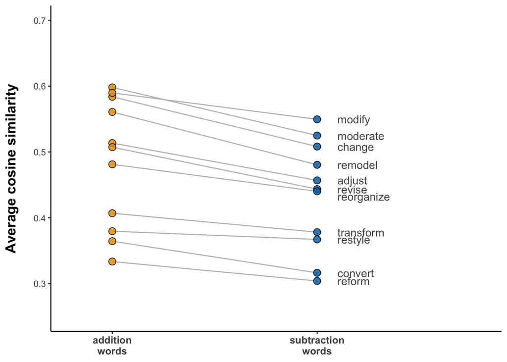

```r
# Define plot and aesthetics:

change_p <- change_long %>%
  ggplot(aes(x = type, y = cosine_verb, fill = type, group = word))

# Add geoms:

change_p <- change_p +
  geom_line(col = 'grey') +
  geom_point(size = 3, shape = 21, alpha = 0.85) +
  annotate(geom = 'text',
           x = rep(2.1, length(sub_cosines)),
           y = sub_cosines,
           label = sub_words,
           hjust = 0,
           col = 'grey33')

# Add scales and axes labels:

change_p <- change_p +
  scale_y_continuous(breaks = seq(0.2, 0.7, 0.1),
                     limits = c(0.2, 0.7)) +
  scale_fill_manual(values = c("#E69F00", "#0072B2")) +
  coord_cartesian(xlim = c(1.3, 2.3),
                  ylim = c(0.25, 0.7)) +
  xlab(NULL) +
  ylab('Average cosine similarity')

# Add themes:

change_p <- change_p +
  theme_classic() +
  theme(legend.position = 'none') +
  theme(axis.title.y = element_text(margin = margin(t = 0, r = 15,
                                                    b = 0, l = 0),
                                    size = 14, face = 'bold'),
        axis.text.x = element_text(face = 'bold', size = 10),
        plot.title = element_text(face = 'bold'))

# Show in markdown:

change_p
```

```r
# Save:

ggsave(plot = change_p,
       filename = '../figures/pdf/change_cosines.pdf',
       width = 3, height = 4)
ggsave(plot = change_p,
       filename = '../figures/png/change_cosines.png',
       width = 3, height = 4)
ggsave(plot = change_p,
       filename = '../figures/tiff/change_cosines.tiff',
       width = 3, height = 4)
```

Now for modeling, set a weakly informative prior centered at zero difference, SD = 0.1 (meaning that a 68% of differences are assumed to be [-0.1, +0.1]; 95% are assumed to be [-0.2, +0.2].

```r
weak_prior <- c(prior('normal(0, 0.1)', class = 'Intercept'))
```

We’ll use the difference scores for this one, which will amount to the equivalent of a Bayesian paired t-test:

The Bayesian model:

```r
change_mdl <- brm(diff_verb ~ 1, # changed to diff_verb after 01/11/2022
                  data = change_cos,
                  prior = weak_prior,

                  # MCMC settings:

                  seed = 42, chains = 4, cores = 4,
                  warmup = 2000, iter = 4000)
```

Check posterior predictive simulations:

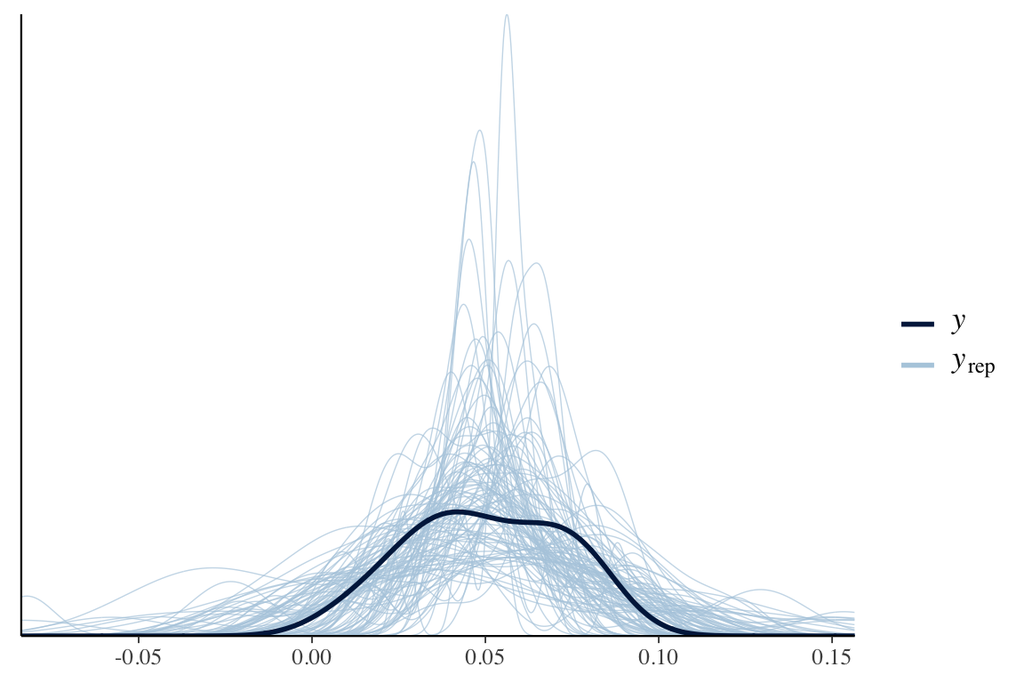

```r
pp_check(change_mdl, nsample = 100)
```

Looks good. The model could possibly have predicted the data.

Check the model:

```r
change_mdl
```

```
##  Family: gaussian
##   Links: mu = identity; sigma = identity
## Formula: diff_verb ~ 1
##    Data: change_cos (Number of observations: 11)
##   Draws: 4 chains, each with iter = 4000; warmup = 2000; thin = 1;
##          total post-warmup draws = 8000
##
## Population-Level Effects:
##           Estimate Est.Error l-95% CI u-95% CI Rhat Bulk_ESS Tail_ESS
## Intercept     0.05      0.01     0.03     0.07 1.00     4456     3898
##
## Family Specific Parameters:
##       Estimate Est.Error l-95% CI u-95% CI Rhat Bulk_ESS Tail_ESS
## sigma     0.03      0.01     0.02     0.04 1.00     3645     3905
##
## Draws were sampled using sampling(NUTS). For each parameter, Bulk_ESS
## and Tail_ESS are effective sample size measures, and Rhat is the potential
## scale reduction factor on split chains (at convergence, Rhat = 1).
```

Perform a test of the posterior probability of the effect being below/above zero.

```r
hypothesis(change_mdl, 'Intercept < 0')
```

```
## Hypothesis Tests for class b:
##        Hypothesis Estimate Est.Error CI.Lower CI.Upper Evid.Ratio Post.Prob
## 1 (Intercept) < 0     0.05      0.01     0.04     0.06          0         0
##   Star
## 1
## ---
## 'CI': 90%-CI for one-sided and 95%-CI for two-sided hypotheses.
## '*': For one-sided hypotheses, the posterior probability exceeds 95%;
## for two-sided hypotheses, the value tested against lies outside the 95%-CI.
## Posterior probabilities of point hypotheses assume equal prior probabilities.
```

```r
hypothesis(change_mdl, 'Intercept > 0')
```

```
## Hypothesis Tests for class b:
##        Hypothesis Estimate Est.Error CI.Lower CI.Upper Evid.Ratio Post.Prob
## 1 (Intercept) > 0     0.05      0.01     0.04     0.06        Inf         1
##   Star
## 1    *
## ---
## 'CI': 90%-CI for one-sided and 95%-CI for two-sided hypotheses.
## '*': For one-sided hypotheses, the posterior probability exceeds 95%;
## for two-sided hypotheses, the value tested against lies outside the 95%-CI.
## Posterior probabilities of point hypotheses assume equal prior probabilities.
```

## Cosines for improve words

Create a tibble to store cosines for each of the change words:

**Update** 01/11/2022: New words added:

```r
improve_cos <- tibble(word = improve_words,
                      add = rep(NA_real_, length(improve_words)),
                      addition = rep(NA_real_, length(improve_words)),
                      subtract = rep(NA_real_, length(improve_words)),
                      subtraction = rep(NA_real_, length(improve_words)),

                      # New words:

                      plus = rep(NA_real_, length(improve_words)),
                      minus = rep(NA_real_, length(improve_words)),
                      more = rep(NA_real_, length(improve_words)),
                      less = rep(NA_real_, length(improve_words)),
                      most = rep(NA_real_, length(improve_words)),
                      least = rep(NA_real_, length(improve_words)),
                      many = rep(NA_real_, length(improve_words)),
                      few = rep(NA_real_, length(improve_words)),
                      increase = rep(NA_real_, length(improve_words)),
                      decrease = rep(NA_real_, length(improve_words)))

# Check:

improve_cos
```

```
## # A tibble: 9 × 15
##   word     add addition subtract subtraction  plus minus  more  less  most least
##   <chr>  <dbl>    <dbl>    <dbl>       <dbl> <dbl> <dbl> <dbl> <dbl> <dbl> <dbl>
## 1 impro…    NA       NA       NA          NA    NA    NA    NA    NA    NA    NA
## 2 enhan…    NA       NA       NA          NA    NA    NA    NA    NA    NA    NA
## 3 better    NA       NA       NA          NA    NA    NA    NA    NA    NA    NA
## 4 upgra…    NA       NA       NA          NA    NA    NA    NA    NA    NA    NA
## 5 amend     NA       NA       NA          NA    NA    NA    NA    NA    NA    NA
## 6 mend      NA       NA       NA          NA    NA    NA    NA    NA    NA    NA
## 7 augme…    NA       NA       NA          NA    NA    NA    NA    NA    NA    NA
## 8 embel…    NA       NA       NA          NA    NA    NA    NA    NA    NA    NA
## 9 ameli…    NA       NA       NA          NA    NA    NA    NA    NA    NA    NA
## # … with 4 more variables: many <dbl>, few <dbl>, increase <dbl>,
## #   decrease <dbl>
```

Fill this with the cosines. We use the fact here that improve_cos has the same order as improve_df:

```r
for (i in 1:nrow(improve_cos)) {
  this_vec <- as.vector(unlist(improve_df[i, -1]))

  # Old columns:

  improve_cos[i, 'add'] <- as.vector(cosine(this_vec, add))
  improve_cos[i, 'addition'] <- as.vector(cosine(this_vec, addition))
  improve_cos[i, 'subtract'] <- as.vector(cosine(this_vec, subtract))
  improve_cos[i, 'subtraction'] <- as.vector(cosine(this_vec, subtraction))

  # New columns:

  improve_cos[i, 'plus'] <- as.vector(cosine(this_vec, plus))
  improve_cos[i, 'minus'] <- as.vector(cosine(this_vec, minus))
  improve_cos[i, 'more'] <- as.vector(cosine(this_vec, more))
  improve_cos[i, 'less'] <- as.vector(cosine(this_vec, less))
  improve_cos[i, 'most'] <- as.vector(cosine(this_vec, most))
  improve_cos[i, 'least'] <- as.vector(cosine(this_vec, least))
  improve_cos[i, 'many'] <- as.vector(cosine(this_vec, many))
  improve_cos[i, 'few'] <- as.vector(cosine(this_vec, few))
  improve_cos[i, 'increase'] <- as.vector(cosine(this_vec, increase))
  improve_cos[i, 'decrease'] <- as.vector(cosine(this_vec, decrease))
}
```

Show this:

```r
improve_cos
```

```
## # A tibble: 9 × 15
##   word     add addition subtract subtraction  plus minus  more  less  most least
##   <chr>  <dbl>    <dbl>    <dbl>       <dbl> <dbl> <dbl> <dbl> <dbl> <dbl> <dbl>
## 1 impro… 0.358    0.283    0.268       0.258 0.252 0.287 0.620 0.595 0.442 0.432
## 2 enhan… 0.620    0.352    0.425       0.237 0.319 0.309 0.402 0.391 0.304 0.365
## 3 better 0.611    0.374    0.425       0.232 0.386 0.318 0.384 0.388 0.285 0.344
## 4 upgra… 0.436    0.402    0.354       0.290 0.355 0.286 0.286 0.290 0.303 0.322
## 5 amend  0.640    0.340    0.502       0.239 0.302 0.304 0.340 0.313 0.285 0.356
## 6 mend   0.640    0.428    0.503       0.305 0.436 0.356 0.361 0.361 0.300 0.261
## 7 augme… 0.340    0.163    0.216       0.170 0.186 0.245 0.272 0.246 0.199 0.284
## 8 embel… 0.499    0.321    0.408       0.241 0.313 0.277 0.317 0.351 0.309 0.365
## 9 ameli… 0.543    0.272    0.448       0.236 0.242 0.188 0.279 0.288 0.217 0.224
## # … with 4 more variables: many <dbl>, few <dbl>, increase <dbl>,
## #   decrease <dbl>
```

Average “add” and “addition” cosine and same for subtraction, then compute a difference score:

```r
improve_cos <- improve_cos %>%
  mutate(add_bias = (add + addition) / 2,
         subtract_bias = (subtract + subtraction) / 2,
         diff = add_bias - subtract_bias)

# Show:

improve_cos
```

```
## # A tibble: 9 × 18
##   word     add addition subtract subtraction  plus minus  more  less  most least
##   <chr>  <dbl>    <dbl>    <dbl>       <dbl> <dbl> <dbl> <dbl> <dbl> <dbl> <dbl>
## 1 impro… 0.358    0.283    0.268       0.258 0.252 0.287 0.620 0.595 0.442 0.432
## 2 enhan… 0.620    0.352    0.425       0.237 0.319 0.309 0.402 0.391 0.304 0.365
## 3 better 0.611    0.374    0.425       0.232 0.386 0.318 0.384 0.388 0.285 0.344
## 4 upgra… 0.436    0.402    0.354       0.290 0.355 0.286 0.286 0.290 0.303 0.322
## 5 amend  0.640    0.340    0.502       0.239 0.302 0.304 0.340 0.313 0.285 0.356
## 6 mend   0.640    0.428    0.503       0.305 0.436 0.356 0.361 0.361 0.300 0.261
## 7 augme… 0.340    0.163    0.216       0.170 0.186 0.245 0.272 0.246 0.199 0.284
## 8 embel… 0.499    0.321    0.408       0.241 0.313 0.277 0.317 0.351 0.309 0.365
## 9 ameli… 0.543    0.272    0.448       0.236 0.242 0.188 0.279 0.288 0.217 0.224
## # … with 7 more variables: many <dbl>, few <dbl>, increase <dbl>,
## #   decrease <dbl>, add_bias <dbl>, subtract_bias <dbl>, diff <dbl>
```

**Update** 01/11/2022: New code chunk that does the same for all addition ones and all subtraction ones. In addition, since these are verbs, we’ll look at all the ones that are verbal.

```r
improve_cos <- improve_cos %>%
  mutate(add_bias_new = (add + addition + plus + more + most + many + increase) / 7,
         subtract_bias_new = (subtract + subtraction + minus + less + least + few + decrease) / 7,
         diff_new = add_bias_new - subtract_bias_new,

         # Verb bias:

         verb_add = (add + increase) / 2,
         verb_subtract = (subtract + decrease) / 2,
         diff_verb = verb_add - verb_subtract)
```

Make this from wide format into long format for plotting and inferential statistics:

**Update** 01/11/2022: New column appended.

```r
improve_long <- improve_cos %>%
  select(word, add_bias, subtract_bias) %>%
  pivot_longer(cols = add_bias:subtract_bias,
               names_to = 'type',
               values_to = 'cosine')

# Long format for new bias measure:

improve_long_new <- improve_cos %>%
  select(word, add_bias_new, subtract_bias_new) %>%
  pivot_longer(cols = add_bias_new:subtract_bias_new,
               names_to = 'type',
               values_to = 'cosine')

# Append:

improve_long$cosine_new <- improve_long_new$cosine

# Long format for new verb bias measure:

improve_long_verb <- improve_cos %>%
  select(word, verb_add, verb_subtract) %>%
  pivot_longer(cols = verb_add:verb_subtract,
               names_to = 'type',
               values_to = 'cosine')

improve_long$cosine_verb <- improve_long_verb$cosine
```

Calculate Cohen’s d for effect size reporting:

```r
suppressWarnings(cohen.d(cosine ~ type, data = improve_long, paired = TRUE))
```

```
##
## Cohen's d
##
## d estimate: 0.944478 (large)
## 95 percent confidence interval:
##     lower     upper
## 0.6301415 1.2588146
```

```r
# Verb for reporting:

suppressWarnings(cohen.d(cosine ~ type, data = improve_long, paired = TRUE))
```

```
##
## Cohen's d
##
## d estimate: 0.944478 (large)
## 95 percent confidence interval:
##     lower     upper
## 0.6301415 1.2588146
```

Change the labels to something more descriptive for plotting:

```r
improve_long <- mutate(improve_long,
                       type = ifelse(type == 'add_bias', 'addition\nwords',
                                     'subtraction\nwords'))
```

Get the words for annotations:

**Update** 01/11/2022: New verb cosines.

```r
sub_words <- filter(improve_long, type == 'subtraction\nwords')$word

# Not verbs (previous):

# sub_cosines <- filter(improve_long, type == 'subtraction\nwords')$cosine

# Verbs (01/11/2022):

sub_cosines <- filter(improve_long, type == 'subtraction\nwords')$cosine_verb
```

Hand-change y-axis positions of labels to prevent overlap:

**Update** 01/22/2022: These are the hand fixed labels for the `cosine` measure that is based on just add/addition versus subtract/subtraction, what we changed now after reviewer 2. So they are commented out here, but there’s new ones for verbs.

```r
# sub_cosines[9] <- sub_cosines[9] + 0.012 # ameliorate slightly up
# sub_cosines[2] <- sub_cosines[2] + 0.009 # enhance slightly up
# sub_cosines[4] <- sub_cosines[4] - 0.02 # upgrade most down
# sub_cosines[8] <- sub_cosines[8] - 0.01 # embellish slightly less down
# # sub_cosines[3] <- sub_cosines[3] - 0.01 # better slightly down

# New verb adjustments:

sub_cosines[6] <- sub_cosines[6] + 0.010
sub_cosines[2] <- sub_cosines[2] - 0.009
```

**Update** 01/11/2022: Saving y-axis breaks from previous plot, just in case. Needs to be readjusted for verb cosines.

```r
# ylim = c(0.15, 0.55)) +
#   scale_y_continuous(breaks = seq(0.1, 0.6, 0.1),
#                      limits = c(0.1, 0.6)) +
```

Make a plot of this:

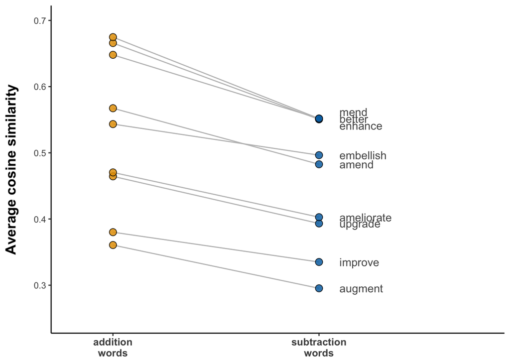

```r
# Define plot and aesthetics:

improve_p <- improve_long %>%
  ggplot(aes(x = type, y = cosine_verb, fill = type, group = word))

# Add geoms:

improve_p <- improve_p +
  geom_line(col = 'grey') +
  geom_point(size = 3, shape = 21, alpha = 0.85) +
  annotate(geom = 'text',
           x = rep(2.1, length(sub_cosines)),
           y = sub_cosines,
           label = sub_words,
           hjust = 0,
           col = 'grey33')

# Add scales and axes labels:

improve_p <- improve_p +
  coord_cartesian(xlim = c(1.3, 2.3),
                  ylim = c(0.25, 0.7)) +
  scale_y_continuous(breaks = seq(0.2, 0.7, 0.1),
                     limits = c(0.2, 0.7)) +
  scale_fill_manual(values = c("#E69F00", "#0072B2")) +
  xlab(NULL) +
  ylab('Average cosine similarity')

# Add themes:

improve_p <- improve_p +
  theme_classic() +
  theme(legend.position = 'none') +
  theme(axis.title.y = element_text(margin = margin(t = 0, r = 15,
                                                    b = 0, l = 0),
                                    size = 14, face = 'bold'),
        axis.text.x = element_text(face = 'bold', size = 10),
        plot.title = element_text(face = 'bold'))

# Show in markdown:

improve_p
```

```r
# Save:

ggsave(plot = improve_p,
       filename = '../figures/pdf/improve_cosines.pdf',
       width = 3, height = 4)
ggsave(plot = improve_p,
       filename = '../figures/png/improve_cosines.png',
       width = 3, height = 4)
ggsave(plot = improve_p,
       filename = '../figures/tiff/improve_cosines.tiff',
       width = 3, height = 4)
```

We’ll use the difference scores for this one, which will amount to the equivalent of a Bayesian paired t-test. We’ll re-use the weakly informative priors from the change verb analysis.

```r
improve_mdl <- brm(diff_verb ~ 1, # new verb addition bias
                  data = improve_cos,
                  prior = weak_prior,

                  # MCMC settings:

                  seed = 42, chains = 4, cores = 4,
                  warmup = 2000, iter = 4000)
```

Check posterior predictive simulations:

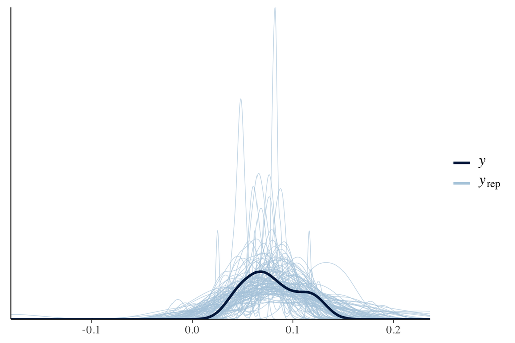

```r
pp_check(improve_mdl, nsample = 100)
```

Looks good. The model could possibly have predicted the data.

Check the model:

```r
improve_mdl
```

```
##  Family: gaussian
##   Links: mu = identity; sigma = identity
## Formula: diff_verb ~ 1
##    Data: improve_cos (Number of observations: 9)
##   Draws: 4 chains, each with iter = 4000; warmup = 2000; thin = 1;
##          total post-warmup draws = 8000
##
## Population-Level Effects:
##           Estimate Est.Error l-95% CI u-95% CI Rhat Bulk_ESS Tail_ESS
## Intercept     0.08      0.01     0.05     0.10 1.00     3707     2981
##
## Family Specific Parameters:
##       Estimate Est.Error l-95% CI u-95% CI Rhat Bulk_ESS Tail_ESS
## sigma     0.03      0.01     0.02     0.06 1.00     3297     2639
##
## Draws were sampled using sampling(NUTS). For each parameter, Bulk_ESS
## and Tail_ESS are effective sample size measures, and Rhat is the potential
## scale reduction factor on split chains (at convergence, Rhat = 1).
```

Perform a test of the posterior probability of the effect being above/below zero.

```r
hypothesis(improve_mdl, 'Intercept < 0')
```

```
## Hypothesis Tests for class b:
##        Hypothesis Estimate Est.Error CI.Lower CI.Upper Evid.Ratio Post.Prob
## 1 (Intercept) < 0     0.08      0.01     0.06      0.1          0         0
##   Star
## 1
## ---
## 'CI': 90%-CI for one-sided and 95%-CI for two-sided hypotheses.
## '*': For one-sided hypotheses, the posterior probability exceeds 95%;
## for two-sided hypotheses, the value tested against lies outside the 95%-CI.
## Posterior probabilities of point hypotheses assume equal prior probabilities.
```

```r
hypothesis(improve_mdl, 'Intercept > 0')
```

```
## Hypothesis Tests for class b:
##        Hypothesis Estimate Est.Error CI.Lower CI.Upper Evid.Ratio Post.Prob
## 1 (Intercept) > 0     0.08      0.01     0.06      0.1    2665.67         1
##   Star
## 1    *
## ---
## 'CI': 90%-CI for one-sided and 95%-CI for two-sided hypotheses.
## '*': For one-sided hypotheses, the posterior probability exceeds 95%;
## for two-sided hypotheses, the value tested against lies outside the 95%-CI.
## Posterior probabilities of point hypotheses assume equal prior probabilities.
```

## Double plots:

Add titles and get rid of second y-axis:

```r
change_p <- change_p +
  ggtitle('(a) Synonyms of "to change"')

improve_p <- improve_p +
  ggtitle('(b) Synonyms of "to improve"') +
  ylab(NULL)
```

Put both together using patchwork:

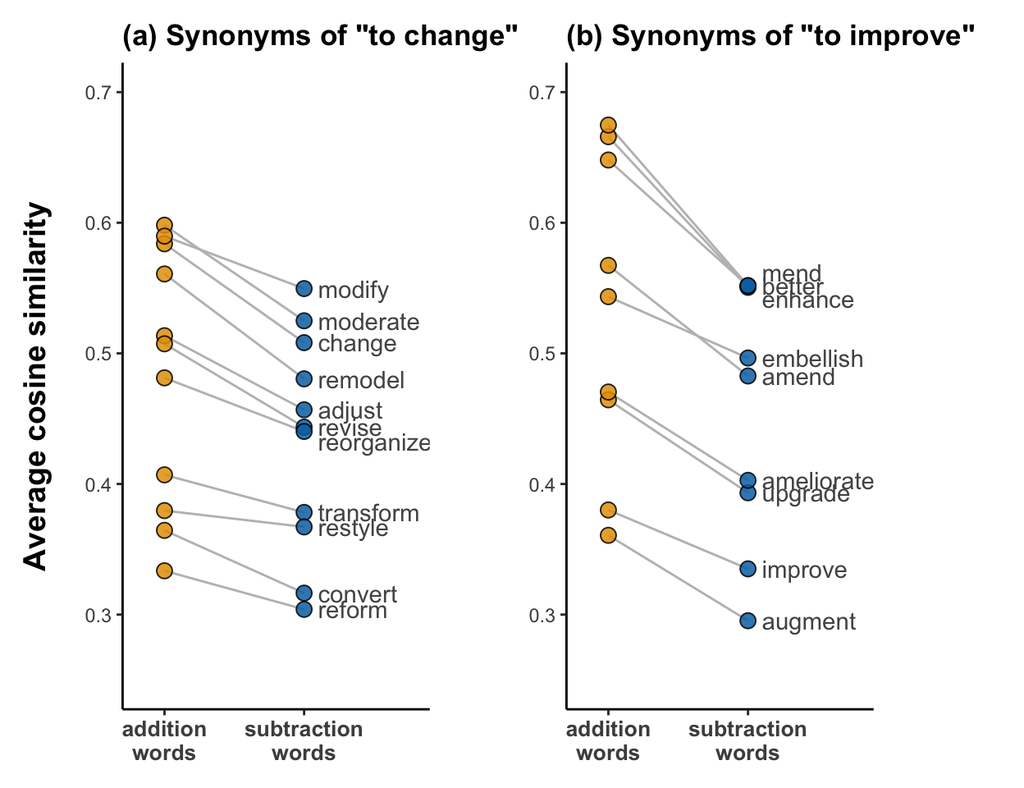

```r
both_p <- change_p + plot_spacer() + improve_p + plot_spacer() +
  plot_layout(widths = c(3, 0.5, 3, 1))

# Show and save:

both_p
```

```r
ggsave(plot = both_p, filename = '../figures/pdf/double_plot.pdf',
       width = 6.5, height = 4)
ggsave(plot = both_p, filename = '../figures/png/double_plot.png',
       width = 6.5, height = 4)
ggsave(plot = both_p, filename = '../figures/tiff/double_plot.tiff',
       width = 6.5, height = 4)
```

Next, the double plot of posterior distributions. First, the plot that has the posterior samples of the `change_mdl`, then the ones of the `improve_mdl`:

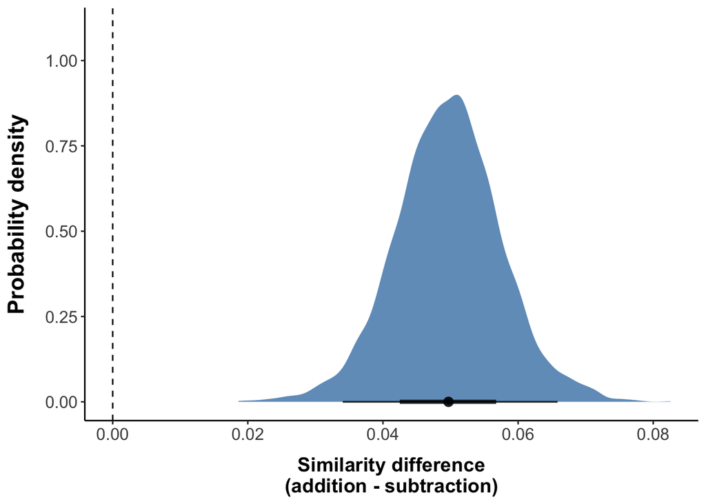

```r
# Plot basics:

change_post_p <- posterior_samples(change_mdl) %>%
  ggplot(aes(x = b_Intercept)) +
  stat_halfeye(fill = 'steelblue', alpha = 0.8) +
  geom_vline(xintercept = 0, linetype = 'dashed')
# Axes and labels:

change_post_p <- change_post_p +
  xlab('Similarity difference\n(addition - subtraction)') +
  ylab('Probability density') +
  coord_cartesian(y = c(0, 1.1)) +
  scale_y_continuous(breaks = seq(0, 1, 0.25))

# Cosmetics:

change_post_p <- change_post_p +
  theme_classic() +
  theme(axis.text.x = element_text(size = 12),
        axis.text.y = element_text(size = 12),
        axis.title.x = element_text(face = 'bold', size = 14,
                                    margin = margin(t = 10)),
        axis.title.y = element_text(face = 'bold', size = 16,
                                    margin = margin(r = 12)))

# Show:

change_post_p
```

Then the `improve_mdl` posteriors:

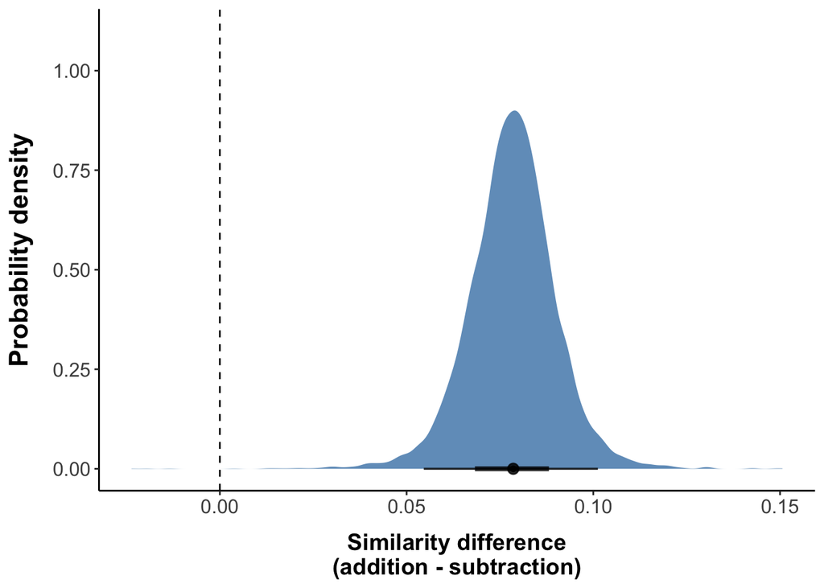

```r
# Plot basics:

improve_post_p <- posterior_samples(improve_mdl) %>%
  ggplot(aes(x = b_Intercept)) +
  stat_halfeye(fill = 'steelblue', alpha = 0.8) +
  geom_vline(xintercept = 0, linetype = 'dashed')
# Axes and labels:

improve_post_p <- improve_post_p +
  xlab('Similarity difference\n(addition - subtraction)') +
  ylab('Probability density') +
  coord_cartesian(y = c(0, 1.1)) +
  scale_y_continuous(breaks = seq(0, 1, 0.25))

# Cosmetics:

improve_post_p <- improve_post_p +
  theme_classic() +
  theme(axis.text.x = element_text(size = 12),
        axis.text.y = element_text(size = 12),
        axis.title.x = element_text(face = 'bold', size = 14,
                                    margin = margin(t = 10)),
        axis.title.y = element_text(face = 'bold', size = 16,
                                    margin = margin(r = 12)))

# Show:

improve_post_p
```

Show both posterior distributions:

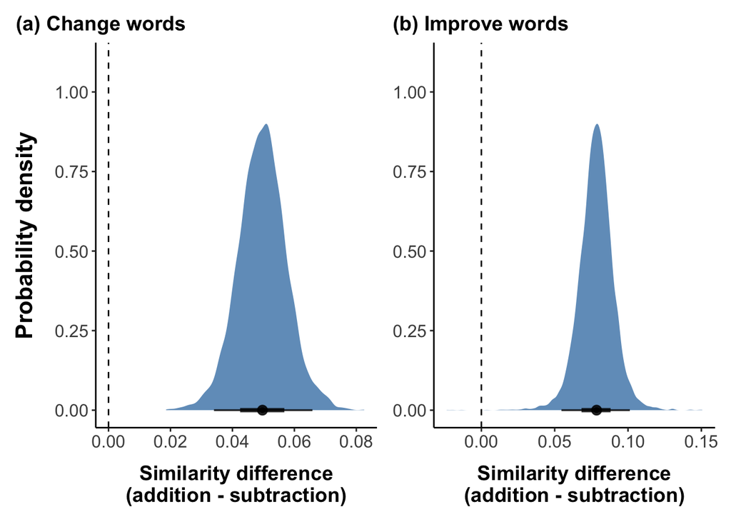

```r
# First plot axes and title:

change_post_p <- change_post_p +
  ggtitle('(a) Change words') +
  theme(plot.title = element_text(size = 14, face = 'bold'),
        plot.title.position = 'plot')

# Second plot axes and title:

improve_post_p <- improve_post_p +
  ylab(NULL) +
  ggtitle('(b) Improve words') +
  theme(plot.title = element_text(size = 14, face = 'bold'),
        plot.title.position = 'plot')

# Combine:

both_p <- change_post_p + improve_post_p

# Show and save:

both_p
```

```r
ggsave(plot = both_p,
       filename = '../figures/pdf/change_improve_posteriors.pdf',
       width = 10, height = 4)
ggsave(plot = both_p,
       filename = '../figures/png/change_improve_posteriors.png',
       width = 10, height = 4)
ggsave(plot = both_p,
       filename = '../figures/tiff/change_improve_posteriors.tiff',
       width = 10, height = 4)
```

## Baseline analysis: all words

Could it be that *all* words are biased towards addition? To assess this, create a distribution of similarity to addition and subtraction for 10,000 randomly selected words from the wiki corpus.

First, select the sub-set:

```r
set.seed(42)
N <- 10000
wiki_10000 <- sample_n(wiki, N)
```

Setup empty vectors to be filled with scores for each word:

```r
add_res <- numeric(N)
increase_res <- numeric(N) # new

subtract_res <- numeric(N)
decrease_res <- numeric(N) # new

# addition_res <- numeric(N)
# subtraction_res <- numeric(N)
```

Loop through the wiki_10000 data frame and compute the average cosine similarities:

```r
for (i in 1:nrow(wiki_10000)) {
  this_vec <- unlist(wiki_10000[i, 2:ncol(wiki_10000)])

  add_res[i] <- as.vector(cosine(this_vec, add))
  increase_res[i] <- as.vector(cosine(this_vec, increase)) # new

  subtract_res[i] <- as.vector(cosine(this_vec, subtract))
  decrease_res[i] <- as.vector(cosine(this_vec, decrease)) # new

  # addition_res[i] <- as.vector(cosine(this_vec, addition))
  # subtraction_res[i] <- as.vector(cosine(this_vec, subtraction))

  if (i %% 100 == 0) cat(str_c(i, '\n'))
}
```

[output not shown]

[output cut: 45 more lines]

[output not shown]

Compute the averages:

```r
# addition_sims <- (add_res + addition_res) / 2
# subtraction_sims <- (subtract_res + subtraction_res) / 2

addition_sims <- (add_res + increase_res) / 2
subtraction_sims <- (subtract_res + decrease_res) / 2
```

Calculate the difference scores and save in tibble:

```r
wiki_diffs <- tibble(diffs = addition_sims - subtraction_sims)
```

Get values for the average “change” verb and “improve” verb difference:

```r
change_diff <- mean(change_cos$diff)
improve_diff <- mean(improve_cos$diff)

# Check:

change_diff
```

```
## [1] 0.08628252
```

```r
improve_diff
```

```
## [1] 0.1036425
```

Check the average for the wiki_10000 diffs:

```r
mean(wiki_diffs$diffs)
```

```
## [1] -0.004103696
```

Good, this is quite different.

Plot this distribution:

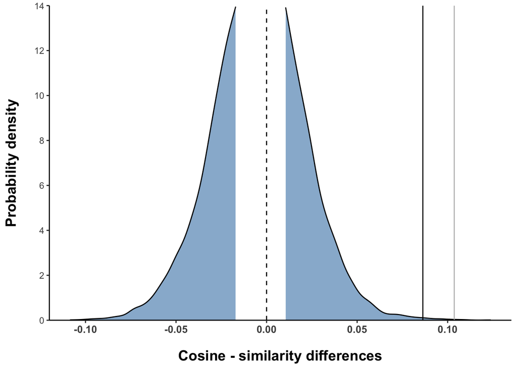

```r
# Setup plot basics:

diff_10000_p <- wiki_diffs %>%
  ggplot(aes(x = diffs)) +
  geom_vline(aes(xintercept = 0), linetype = 'dashed')  +
  geom_density(fill = 'steelblue', alpha = 0.6) +
  geom_vline(aes(xintercept = change_diff)) +
  geom_vline(aes(xintercept = improve_diff), col = 'grey')

# Scales and axes:

diff_10000_p <- diff_10000_p +
  scale_y_continuous(expand = c(0, 0), limits = c(0, 14),
                     breaks = seq(0, 14, 2)) +
  xlab('Cosine - similarity differences') +
  ylab('Probability density')

# Cosmetics:

diff_10000_p <- diff_10000_p +
  theme_classic() +
  theme(axis.title.y = element_text(margin = margin(t = 0, r = 15,
                                                    b = 0, l = 0),
                                    size = 14, face = 'bold'),
        axis.title.x = element_text(margin = margin(t = 15, r = 0,
                                                    b = 0, l = 0),
                                    size = 14, face = 'bold'),
        axis.text.x = element_text(face = 'bold', size = 10),
        plot.title = element_text(face = 'bold'))

# Show and save:

diff_10000_p
```

```r
ggsave(plot = diff_10000_p,
       filename = '../figures/pdf/random_10000_comparison.pdf',
       width = 6, height = 3)
ggsave(plot = diff_10000_p,
       filename = '../figures/png/random_10000_comparison.png',
       width = 6, height = 3)
ggsave(plot = diff_10000_p,
       filename = '../figures/tiff/random_10000_comparison.tiff',
       width = 6, height = 3)
```

What percentile is the change / improve verb similarity?

```r
percentile <- ecdf(wiki_diffs$diffs)
percentile(change_diff)
```

```
## [1] 0.9986
```

```r
percentile(improve_diff)
```

```
## [1] 0.9997
```

## Baseline analysis: Verbs only

The last analysis was focused on all words. But a more appropriate baseline may be verbs. So let’s select 10000 random verbs from the ELP that are not among our target words:

```r
set.seed(666)
N <- 10000

verbs <- filter(ELP, POS == 'VB',
                !Word %in% c(change_words, improve_words)) %>%
  sample_n(N) %>%
  pull(Word)
```

First, select the sub-set:

```r
verbs_10000 <- filter(wiki, word %in% verbs)
```

Setup empty vectors to be filled with scores for each word:

```r
add_res <- numeric(nrow(verbs_10000))
increase_res <- numeric(nrow(verbs_10000))

subtract_res <- numeric(nrow(verbs_10000))
decrease_res <- numeric(nrow(verbs_10000))

# addition_res <- numeric(nrow(verbs_10000))
# subtraction_res <- numeric(nrow(verbs_10000))
```

Loop through the verbs_10000 data frame and compute the average cosine similarities:

```r
for (i in 1:nrow(verbs_10000)) {
  this_vec <- unlist(verbs_10000[i, 2:ncol(verbs_10000)])

  add_res[i] <- as.vector(cosine(this_vec, add))
  increase_res[i] <- as.vector(cosine(this_vec, increase))

  subtract_res[i] <- as.vector(cosine(this_vec, subtract))
  decrease_res[i] <- as.vector(cosine(this_vec, decrease))

  # addition_res[i] <- as.vector(cosine(this_vec, addition))
  # subtraction_res[i] <- as.vector(cosine(this_vec, subtraction))

  if (i %% 200 == 0) cat(str_c(i, '\n'))
}
```

[output not shown]

Compute the averages:

```r
# addition_sims <- (add_res + addition_res) / 2
# subtraction_sims <- (subtract_res + subtraction_res) / 2

addition_sims <- (add_res + increase_res) / 2
subtraction_sims <- (subtract_res + decrease_res) / 2
```

Calculate the difference scores and save in tibble:

```r
verbs_diffs <- tibble(diffs = addition_sims - subtraction_sims)
```

Append this with the names:

```r
verb_cosines <- bind_cols(select(verbs_10000, word), verbs_diffs)

write_csv(verb_cosines, '../data/verb_cosines.csv')
```

Get values for the average “change” verb and “improve” verb difference:

```r
change_diff <- mean(change_cos$diff)
improve_diff <- mean(improve_cos$diff)

# Check:

change_diff
```

```
## [1] 0.08628252
```

```r
improve_diff
```

```
## [1] 0.1036425
```

Check the average for the verbs_10000 diffs:

```r
mean(verbs_diffs$diffs)
```

```
## [1] 0.0312573
```

Good, this is quite different.

Plot this distribution:

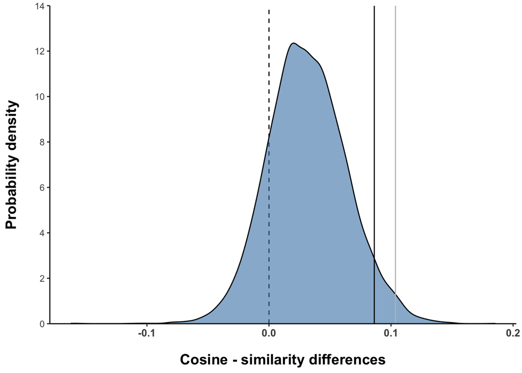

```r
# Setup plot basics:

diff_verb_p <- verbs_diffs %>%
  ggplot(aes(x = diffs)) +
  geom_vline(aes(xintercept = 0), linetype = 'dashed')  +
  geom_density(fill = 'steelblue', alpha = 0.6) +
  geom_vline(aes(xintercept = change_diff)) +
  geom_vline(aes(xintercept = improve_diff), col = 'grey')

# Scales and axes:

diff_verb_p <- diff_verb_p +
  scale_y_continuous(expand = c(0, 0), limits = c(0, 14),
                     breaks = seq(0, 14, 2)) +
  xlab('Cosine - similarity differences') +
  ylab('Probability density')

# Cosmetics:

diff_verb_p <- diff_verb_p +
  theme_classic() +
  theme(axis.title.y = element_text(margin = margin(t = 0, r = 15,
                                                    b = 0, l = 0),
                                    size = 14, face = 'bold'),
        axis.title.x = element_text(margin = margin(t = 15, r = 0,
                                                    b = 0, l = 0),
                                    size = 14, face = 'bold'),
        axis.text.x = element_text(face = 'bold', size = 10),
        plot.title = element_text(face = 'bold'))

# Show this & Save this:

diff_verb_p
```

```r
ggsave(plot = diff_verb_p,
       filename = '../figures/pdf/random_10000_verb_comparison.pdf',
       width = 6, height = 3)
ggsave(plot = diff_verb_p,
       filename = '../figures/png/random_10000_verb_comparison.png',
       width = 6, height = 3)
ggsave(plot = diff_verb_p,
       filename = '../figures/tiff/random_10000_verb_comparison.tiff',
       width = 6, height = 3)
```

What percentile is the change / improve verb similarity?

```r
percentile <- ecdf(verbs_diffs$diffs)
percentile(change_diff)
```

```
## [1] 0.9507546
```

```r
percentile(improve_diff)
```

```
## [1] 0.983547
```

## Double plot

Put both plots together:

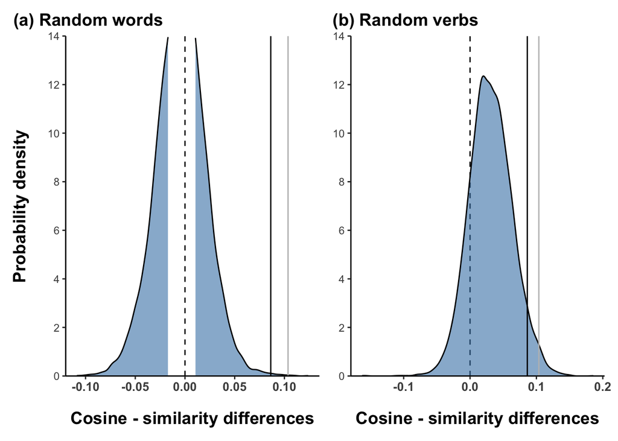

```r
# First plot title and axes:

diff_10000_p <- diff_10000_p +
  ggtitle('(a) Random words') +
  theme(plot.title = element_text(size = 14, face = 'bold'),
        plot.title.position = 'plot')

# Second plot title and axes:

diff_verb_p <- diff_verb_p +
  ylab(NULL) +
  ggtitle('(b) Random verbs') +
  theme(plot.title = element_text(size = 14, face = 'bold'),
        plot.title.position = 'plot')

# Combine:

both_p <- diff_10000_p + diff_verb_p

# Show and save:

both_p
```

```r
ggsave(plot = both_p,
       filename = '../figures/pdf/double_cosine_distributions.pdf',
       width = 10, height = 4)
ggsave(plot = both_p,
       filename = '../figures/png/double_cosine_distributions.png',
       width = 10, height = 4)
ggsave(plot = both_p,
       filename = '../figures/tiff/double_cosine_distributions.tiff',
       width = 10, height = 4)
```

This completes this analysis.